# 韓國瑜 & 陳其邁 2018 年 9 月臉書資料文本分析

Pecu Tsai

2019年3月25日

## 讀取 2018 年 9 月的臉書資料 (Q Search 提供)

## 只取出貼文是含有 Video 的部分來進行分析

```r
library(readr)
X201809_data <- read_csv('~/GitHub/data/201809_data.csv')
library(tidyverse)
VideoMatrix = filter(X201809_data, Type == "video")
Hvideo = filter(VideoMatrix, grepl("韓國瑜", VideoMatrix$Page_Name) == TRUE)
Cvideo = filter(VideoMatrix, grepl("陳其邁", VideoMatrix$Page_Name) == TRUE)
Hcomment = Hvideo[,c(2,13,15)]
Ccomment = Cvideo[,c(2,13,15)]
HCComment = rbind(Hcomment, Ccomment)
library(kableExtra)
kable(head(HCComment))
```

| Page_Name | Comment_Count | Message |
| --- | --- | --- |
| 韓國瑜 | 110 | 【國瑜上菜啦】 我很愛吃，也自覺很懂吃。時常跟我的孩子們說，看一家廚師功夫好不好，要看的不是什麼招牌美食；只要最平凡普通的空心菜跟蛋炒飯，就可見餐廳實力！ 因為這場選舉，我這幾個月煮的飯比結婚這幾十年來還多！所以週末夜晚跟大家分享我的上菜秀，看看我的實力怎麼樣，夠不夠格做大廚！ https://youtu.be/dCHSyvxyX_I |
| 高雄選韓國瑜News | 73 | 選戰倒數，短兵相接 韓國瑜和陳其邁今天終於同框了！ 期待高雄市今年有一場光榮的選舉。🌞 韓粉們大家趕快去拉票，展現我們的風度，把韓國瑜的排名從坐二望一，推到第一。💪💪💪 ✌️翻轉高雄Yes，we can！ 👉新聞來源: 中天新聞 https://youtu.be/rbE2QJrbuHI #韓陳相遇議員們在台下好興奮 #君子之爭CanWe |
| 高雄選韓國瑜News | 21 | 一場大水，讓我們必須更嚴肅去面對台灣的災害管理學。 韓國瑜近期將邀請李鴻源教授為高雄治水把脈。 👉影片來源：大愛電視人文講堂 李鴻源談災害管理 http://www.youtube.com/watch?v=qiA4V0KYVXU 👉新聞來源：聯合新聞網 https://udn.com/news/story/7327/3343666 |
| 韓國瑜民間粉絲團（志工團 | 55 | 韓國瑜總是很大氣滴！😎 https://m.youtube.com/watch?feature=youtu.be&v=rbE2QJrbuHI ＃韓國瑜 |
| 高雄選韓國瑜News | 39 | 93軍人節，韓國瑜向勞苦功高的軍人致意！很感人。 韓國瑜18歲唸軍校，父親是軍人，岳父原本連一句國語都不會，當兵抽到金門，剛好遇到823炮戰，退伍後也是榮民，全家幾乎都是軍人，對於軍人，軍眷的心情，特別能感同身受。 韓國瑜感慨地說：現今軍人的地位不如以往「大家委屈了」。 他分享之前當立法委員時，立法院在審查眷村改建條例，朝野可以說是從台下打到台上，打到台上再繼續打，「當初如果不是這樣拼，以現在的政… |
| 韓國瑜民間粉絲團（志工團 | 46 | 朱學恆的 雞排危機 韓國瑜 ＃所以要票投韓國瑜哦！ |

## 畫出韓國瑜 & 陳其邁的發文數量以及讀者回文數量

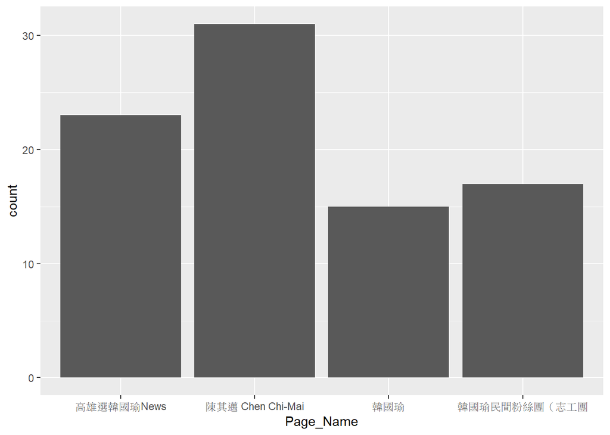

```r
library(ggplot2)
ggplot() + geom_bar( data = HCComment, aes(x=Page_Name) )
```

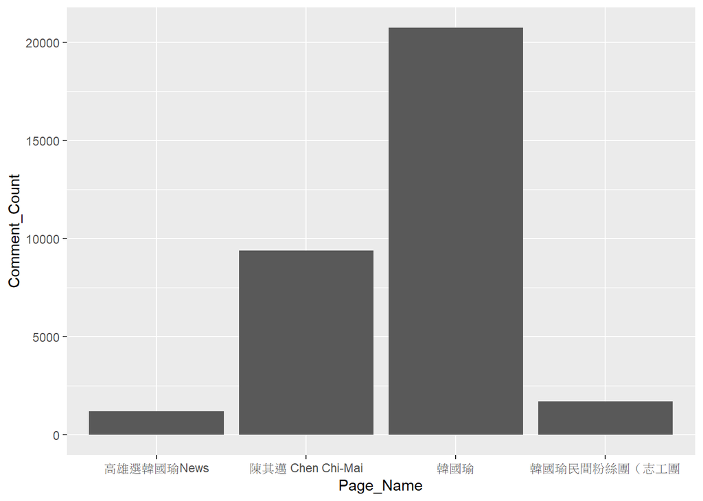

```r
ggplot() + geom_bar( data = HCComment,
                     aes(x=Page_Name, y=Comment_Count, group = Page_Name),
                     stat="identity")
```

陳其邁在 Video 的發文數比韓國瑜多，但韓國瑜的回文數卻高於陳其邁，需要討論，2018年九月韓國瑜竄起時，為何會有這麼多回文，遠高於長期耕耘高雄的陳其邁？

## 依照 page 來源，將同一 page 不同發文時間的文章進行合併

```r
HCmessage = HCComment %>% group_by(Page_Name) %>%
  mutate(messageByName = paste0(Message, collapse = ""))
id = which(duplicated(HCmessage$Page_Name) == FALSE)
HCmessageAll = HCmessage[id,c(1,4)]
kable(head(HCmessageAll))
```

Page_Name

messageByName

韓國瑜

【國瑜上菜啦】

我很愛吃，也自覺很懂吃。時常跟我的孩子們說，看一家廚師功夫好不好，要看的不是什麼招牌美食；只要最平凡普通的空心菜跟蛋炒飯，就可見餐廳實力！

因為這場選舉，我這幾個月煮的飯比結婚這幾十年來還多！所以週末夜晚跟大家分享我的上菜秀，看看我的實力怎麼樣，夠不夠格做大廚！

https://youtu.be/dCHSyvxyX_I【貳零壹捌玖月柒日】

今天是2018年9月7日。 我來到高雄市黨部正好屆滿一周年。

這一年來，我在高雄上山下海、走街串巷，學習了許多，也發現了許多。

在我的心目中，高雄鄉親的熱情、好客、勤奮、古意，就是這座壯麗的海港城市中最美的風景，加上高雄又有海陸空全方位的天然優勢，其實完全可以像上海或紐約一樣，成為一座擁抱經濟、遠離政治的賺錢城市！

希望再過八十幾天，我能有機會與各位一起鬥陣作伙拚經濟、爭幸福，打造高雄成為台灣的首富之都！【一起輕旅行】

幾周前走訪高雄佛光山佛陀紀念館以及旗山等各處錄製的旅遊節目預告終於出爐！

還記得那天晴空萬里，雲一朵朵疊層在湛藍的天空，那時和主持人與導覽員走在佛陀紀念館，就好像身心靈都被洗滌了一番。

港都美食遍地，帶著主持人吃著旗山香蕉口味的限定餅乾蛋糕還有新鮮海鮮、酸菜白肉鍋……想起那天，很是精彩。

歡迎本周六晚上八點鎖定57頻道東森財經新聞台，跟我一起高雄輕旅行，下次來到這也走一回我的推薦行程！

https://goo.gl/khPQ1d與 氣象達人彭啟明 深度對談，防災更勝於救災！高雄，許個願！如果能為家鄉許個願望，你最想實現的是什麼？ 今天再度與米魯合體，聽聽鄉親們的願望，再過70天，願我能為各位實現！今日與嘉義市長候選人 黃敏惠 一同享用嘉義有名的雞肉飯共度午餐會談，聊聊拼經濟、建設、觀光還有未來嘉義及高雄的發展合作，共創雙城產業繁榮！我要的是真真實實的民意，不是起起伏伏的民調。 加油，讓我們一起改變高雄！團隊的主視覺出爐了！Logo主體取自高雄的「高」，還有代表著不忘與基層站同一陣線的斗笠與高麗菜。

複雜的腦，單純的心，純粹的設計，就這麼簡單。【主視覺設計理念】

以較為低調的色系展現質感、風度以及層次，除了象徵內斂的風度外也體現單純的要將高雄打造為全台首富的決心。

Logo主體取自高雄的「高」字，上面的斗笠與中間具代表性的高麗菜，象徵草根性，同時也代表永不忘與基層站在同一陣線的初衷。

有別於使用亮麗色彩，簡單幾何線條的質感更凸顯內斂、言之有物、有理沉穩、曖曖內含光的性格，並期待高雄烏雲散去，終會有耀眼光芒的純粹本質。

複雜的腦，單純的心，純粹的設計，就這麼簡單。【當個勇敢去闖的年輕人】

小時候我就不是一個聽話的小孩。

我曾唸過資優班後來因為交女朋友而來到了放牛班；當年也毅然決然的離開政壇跑到山上「隱居」……不論是人生的哪一段，我總是會做出讓人意外的選擇。

但也是因為這些選擇，讓我有不一樣的思考方式、不一樣的人生哲學。我常鼓勵年輕人，不要害怕去闖，這些闖蕩終會成為人生重要的養分，不經意地散發光芒。

那天團隊無意間傳來這首Rap，聽到自己的聲音真是嚇了一跳，結果原來是支持者親自作詞作曲，真的讓我覺得非常有才華同時也感到溫馨！我也想藉此鼓勵年輕人，你們的青春、創新、活力與堅持，將會帶來全新的時代，而我們的任務就是把這環境建立好，讓你們有更堅強的後盾，不畏懼的向前發光發熱。

所以，年輕的朋友們，不要害怕去闖，並為自己的闖蕩負責。三十歲以前不要怕，六十歲以後不要悔！不論哪個年紀，都讓我們當個勇敢去闖的「年輕人」。

https://www.youtube.com/watch?v=a8YHpNXhI84&feature=youtu.be為年輕人，找到一條回家的路！這個中秋假期夜晚，讓我與年輕人談天說地，聊聊我們、你們的未來！今日神明義工，祈求高雄平安。受岡山九皇宮之邀，參與繞境進香義工，希望今年天災少一點，工商賺大錢，農漁民過好年。【一陽破九陰】

針對某些人士指控我蓋賭場、消滅母語，在這裡只有兩件事要澄清。

第一：主張修正離島建設條例，讓旗津區可以適用離島建設條例成為免稅區，成立觀光賭場不是旗津區未來發展選項。

第二：堅持中英文雙語教育政見，與母語學習環境並無衝突也無打壓。

未來在使用電蚊拍以及扣帽子前，請先多多尊重高雄鄉親的聲音與福祉，來一場君子之爭。

https://m.youtube.com/watch?v=sAcFvDQvLT0&feature=youtu.be【關於領導】

我們都在領導與被領導，而這個課題也是我們畢生都在學習的。

關於領導，我認為，一個首長最重要的三件事：第一樹立總目標、第二以身作則、第三運用操守好、有熱情理想、會做事的團隊！

而讓高雄變得又年輕又有錢，就是我的總目標；在這目標之下，我身體力行，不汙不貪，自然上行下效；最後重用人才，因為一個人走得快，一群人才能走得遠。

完整影片：https://www.youtube.com/watch?v=e3zROpNRC_k午安，直播開始囉！歡迎點閱看我與主持人「韓國魚」郭子乾、楊琇晶的《市長進行式》！

高雄選韓國瑜News

選戰倒數，短兵相接 韓國瑜和陳其邁今天終於同框了！

期待高雄市今年有一場光榮的選舉。🌞 韓粉們大家趕快去拉票，展現我們的風度，把韓國瑜的排名從坐二望一，推到第一。💪💪💪

✌️翻轉高雄Yes，we can！

👉新聞來源: 中天新聞 https://youtu.be/rbE2QJrbuHI

# 韓陳相遇議員們在台下好興奮 #君子之爭CanWe一場大水，讓我們必須更嚴肅去面對台灣的災害管理學。

韓國瑜近期將邀請李鴻源教授為高雄治水把脈。

👉影片來源：大愛電視人文講堂 李鴻源談災害管理 http://www.youtube.com/watch?v=qiA4V0KYVXU

👉新聞來源：聯合新聞網 https://udn.com/news/story/7327/334366693軍人節，韓國瑜向勞苦功高的軍人致意！很感人。

韓國瑜18歲唸軍校，父親是軍人，岳父原本連一句國語都不會，當兵抽到金門，剛好遇到823炮戰，退伍後也是榮民，全家幾乎都是軍人，對於軍人，軍眷的心情，特別能感同身受。

韓國瑜感慨地說：現今軍人的地位不如以往「大家委屈了」。

他分享之前當立法委員時，立法院在審查眷村改建條例，朝野可以說是從台下打到台上，打到台上再繼續打，「當初如果不是這樣拼，以現在的政治氛圍要通過可能更難上加難！」…

身為在野黨，93軍人節的規模不大，但現場的氣勢如虹，凝聚力強，也期待明年在高雄市政府前廣場擴大慶祝軍人節。最強菜販韓國瑜，能讓綠地變藍天嗎？

高雄市長最新民調出爐，陳其邁36.7%：韓國瑜31% ，有40%受訪女性尚未決定！！ 選情呈現五五波，進入衝刺階段！韓粉們大家再加把勁，一拉十，十拉百，陪韓國瑜一起衝向終點，奪標！

讓高雄找回光榮，這一票為下一代而投，幫年輕人找一條回鄉的路。

👉新聞來源：雲端最前線 https://youtu.be/e0eTisSmX-A

#高雄市議員陳美雅💯 #呼喚北漂青年記得回來投票韓國瑜、陳宜民、張善政 共同《為偏鄉把脈，傾聽杉林聲音》。

🌟時間:下午2點40分 🌟地點:朝雲宮(杉林區月眉活動中心旁媽祖廟，清水路朝雲巷10號

為了縮小高雄市的城鄉差距，國民黨高雄市長候選人韓國瑜（5）日特地邀請前行政院長張善政、立委陳宜民、高雄市前議長許崑源、市議員候選人林義迪、杉林區農會總幹事吳俊德等人，在杉林區的老人活動中心舉行。

杉林區座談會當地居民反映，杉林區有議員，但完全沒有公共建設，好像是二等公民，例如申請裝自來水，居民還要分擔 「路修費」及 「工程費」，獨居老人的子女如果不出這筆錢，他們根本繳不起。

韓國瑜表示，杉林區地處偏遠，但因空氣好、土壤、水質沒有受汙染，地方以生產各種瓜類聞名，包括木瓜自創品牌「紅孩兒」，不同南瓜品種發展出綠色「一品夫人」、白色的「詩人李白」、紅色的「旭日東升」，還有絲瓜、苦瓜、胡瓜都非常有特色。

韓國瑜說，農民什麼都不怕，就怕沒有訂單，未來他當選市長以後，市政府一定會帶頭幫農民搶訂單，並發展偏鄉的特色農業經濟，以及去除農產運銷的中間剝削，增加農民的收益。

為了縮小城鄉差距，韓國瑜認為，在地的議員最了解偏鄉地區的需求，最了解那些建設可以拉近鄉城的差距。他未來也會聘請張善政擔任高雄市發展高科技經濟的最重要指導顧問。

陳宜民表示，杉林區有最好的瓜類農產品，每年的瓜瓜節都吸引了大量人潮，他相信韓國瑜當選市長以後，市政府一定可以結合農產品跟觀光特色，讓偏鄉的經濟往上提昇。

張善政說，韓國瑜是第一位賣菜出身的市長候選人，最能理解農民的辛勞，他看到高雄市淹水期間，韓國瑜在第一時間打赤腳到淹水區苦民所苦，他相信如果韓國瑜可以當選市長，一定會好好照顧農民。

杉林區農會總幹事吳俊德的腳部受傷，今天還是撐著四腳拐趕到會場支持。吳俊德說，他結婚前，選舉只投民進黨，好像是神主牌一樣，但他後來發現民進黨只會騙選票，真正在做事的還是國民黨。他呼籲高雄市的選民一定要覺醒，一定要支持最照顧農民的韓國瑜。運輸業者聯袂公開力挺韓國瑜，拼經濟救觀光

高雄市在地運輸產業界大老（3）日聯袂公開表態支持韓國瑜，認同韓國瑜主張高雄市全面拚經濟的理念，希望韓市長勇敢往前衝，大家都是支持他的。

高雄市政顧問、前監理處處長廖金得表示，民進黨真的做的太差，是個「賊黨」！就他的觀察，以前支持民進黨的，現在都反了。

隨行公開力挺的運輸業者大老包括：高雄直轄市汽車商業同業公會理事長黃棟樑、高雄市計程車商業同業公會理事長甘光華、高雄市道安促進會理事長梁郁哲、中華民國汽車代檢協會理事長黃順義、汽車鑑價協會理事長陳豐進、高雄市遊覽車商業同業公會理事長楊福泰、高雄市汽車駕駛員職業工會理事長洪秋鳳、計程車無線電台協會吳政和、高雄市汽車商業公會陳義雄等人。

廖金得表示，既然敢率運輸業界挺韓國瑜，就不怕綠營秋後算帳，高雄經濟倒退不振，觀光衰退，運輸業的感受最深刻。很多熱心網友主動製作宣傳影片，讓人感受到這是一場大家的選舉，年底高雄市長選舉，這一票為高雄的明天、為下一代而投。

北漂青年將是勝負關鍵，11／24🐟“歸瑜”“返鄉吧！

# 打造高雄全台首富 #堅定唯一支持韓國瑜

https://youtu.be/FaDUcjvmzbg重播韓國瑜離開台北農產時與所有部屬深情擁抱的畫面！

中秋節快到了，北農員工應該很懷念這位很會幫農民、處處為員工設想的韓總吧。

韓國瑜去年3月31日正式卸任北農總經理，很多員工都哭紅了眼眶，證明他做人成功，除了平易近人，帶人而且帶心。

韓國瑜經營北農，除了業績年年創新高，最讓人印象深刻的是他在果菜市場提倡書香社會，每個月買書給員工，鼓勵大家讀書，看完書交心得報告發1000獎金。請英文老師來幫大家上課，員工去進修大學、研究所公司補助學費。

2016年端午節發放給員工的獎金是每人5萬元，中秋節發放的獎金是9萬元！由於北農一度頻臨倒閉，所有員工曾減薪10％到15％，迄今未調回來。韓國瑜擔任北農總經理時，對於端午節、中秋節獎金的發放採取齊頭式平等的發放方式，也就是總經理跟工友都是領取一樣的金額，藉此來彌補員工以往減薪遭受的損失。

https://youtu.be/-SDXUMRB5lo許多政治人物辯才無礙，但很少有人像韓國瑜熟讀歷史、引經據典，最重要的是他用庶民語言，大家都聽得懂「賺錢！賺錢！再賺錢」。

有熱心網友整理《充滿學問的韓國瑜》影片，和大家分享。

https://youtu.be/I95aqrY0x0U

# 故宮的國寶遷移來台的秘史 #萬里長城如何驗收11/24 大家能接受韓國瑜“雖敗猶榮”的結果嗎？

感謝花蓮身障小農捐出1000碗滷肉飯支持韓國瑜！ 他說：“ 電視上所有評論、名嘴都說韓國瑜人品口才能力都非常好，這一仗打得非常棒，但是最後他不會當選，會雖敗猶榮。” 實在嚥不下這口氣…

選情進入黃金死亡交叉點，年底能不能翻轉高雄，拜託大家一拉十、十拉百，讓韓國瑜帶領高雄重返榮耀！🙏🙏🙏

https://www.youtube.com/watch?v=TKnU6sUBMVQ💡有創意的政府找方法

關於台北農產改建，到底哪一個是韓國瑜版本？

👉新聞來源：POP Radio《POP搶先爆》 https://www.youtube.com/watch?v=5fe-GpLfgTo

# 台北市可以不花一毛錢改建市場保證第一次首播 歡迎分享。

很潮的韓國瑜….感謝張殿昀長期以來支持。

“東西賣得出去，人進得來，高雄要發大財！” Let’s Get That Money!

歡迎更多粉絲創作….協助推動高雄發大財！

https://youtu.be/a8YHpNXhI84之前被民進黨抹黑韓國瑜跳舞事件而聲名大噪的 奇異果樂團，今天晚上在自來水公園由陳若翠-微笑加油讚舉辦的中秋節{月來樂美麗}音樂晚會再度登台，團長與韓國瑜合唱一首〈月亮代表我的心〉！

韓國瑜表示，有人問他會不會後悔去參加那場活動，他一點都不後悔，如果可以振興高雄觀光，讓他在地上翻跟斗都願意！

# 歌聲出乎意料的優美 #奇異果樂團 #祝大家中秋節快樂https://youtu.be/2_fUvZIjVjo如果可以留在家鄉陪伴父母，誰願意漂流異鄉呢？

聽聽一個27歲在外打拼的高雄年輕人的心聲，有多少高雄囝仔想要回家？

“因為韓國瑜，讓我再一次願意相信政治”

11／24讓我們一起幫高雄的孩子，找到一條回家的路。

http://www.youtube.com/watch?v=vRE52fNnP1A&feature=youtu.be

# 找回高雄的榮耀 #我是高雄人我投韓國瑜中秋節和北漂的年輕人談天說地，聊聊大家對高雄未來的想像！

直播網址👉🏻 https://bit.ly/2O0TOJ3非典型政治人物，韓國瑜“跑”選舉行程，進場的方式也很非典型。😅

韓國瑜推動雙語教育，被民進黨抹黑是要打擊客家文化！22日在美濃韓國瑜反擊神回：民進黨除了說他是「很醜大禿頭」其餘他一概不承認。

民進黨選舉不抹黑就不會選舉，真是可憐。

https://bit.ly/2N23Oxq📣請支持者全面戒備，民進黨的奧步來了！

民進黨正傾全力發動攻勢抹黑韓國瑜！

民進黨選舉奧步一貫SOP ：自導自演，斷章取義，先扭曲再抹黑。

民進黨最近瘋傳韓國瑜到「美濃造勢會人山人海」是假新聞？

還原9/22日韓國瑜在美濃高美醫專的影片，現場座無虛席，且沒有一輛遊覽車，都是支持民眾主動參加。 https://youtu.be/Djzjq_3hd7k

至於網傳誤植國軍英雄館為高美醫專的照片，並非韓國瑜官方團隊發出新聞照片。為網友誤傳，或民進黨自導自演，先栽贓再抹黑？

本身也是客家人的林郁芳看到這個場面：「我開始相信韓國瑜會當選！」

不過可以證明一件事：民進黨真的是急了，看到韓國瑜所到之處，人氣紅不讓，只能到處抹黑一切都是假新聞。

# 拒絕奧步 #民進黨不抹黑就不會選舉 #堅定支持韓國瑜你知道 高雄市政府 賣多少地嗎？

高雄市政府過去12年賣公有地高達16.7萬坪，比邦交國梵諦岡面積還大!😰

賣掉一個國家大的土地也算是一項紀錄了😱 請問民進黨執政的市政府，除了賣地還債高雄還剩下什麼能做？要市民如何再❛相信高雄❜ 給民進黨繼續“邁”？

👉影片來源： 高雄市議員陳麗娜

https://youtu.be/nWEGJNPgH9Q📣📣Yahoo TV 一起看〈市長進行式〉 與 三立新聞〈94要客訴〉 9 /28（五）中午12:00-13:00到高雄直播！

郭子乾首度飾演 韓國魚，當韓國瑜遇上韓國魚 高雄未來更光明！節目將邀請神秘嘉賓🗣️，保證精采。

🔔活動地點：楠梓煉油廠宏南訓練教育中心（楠梓區宏毅一路12巷2號）捷運紅線世運站2號出口，步行約3分鐘。

🌟現場開放民眾參加，請於上午11：00前入場，現場座位有限，額滿為止。

🚫請勿攜帶競選旗幟、標語、帽子及背心進場。

Yahoo!TV 直播網址 ( 打開Yahoo首頁)https://tw.tv.yahoo.com/wtn-mayoring/ 或三立新聞網臉書粉絲頁、youtube首頁。

https://www.facebook.com/YahooTWNews/videos/2179994938956099/韓國瑜的選舉有如一場驚奇之旅！ 韓國瑜：「我今天是把壓在孫悟空五百年那座五指山，上面的咒語揭開了，孫悟空跳出來了，高雄人已經變了。」

十個月前絕對沒有人相信，韓國瑜的選戰可以打到今天的局面。一場非典型的選戰，正在高雄創造奇蹟…

民進黨最近每日一黑，但他們真的是低估人民的智慧 奧步越多只會越發讓人瞧不起這個政黨。

高雄加油！韓國瑜加油！ 11/24 讓執政不力的民進黨，懂得什麼是謙卑！

👉影片來源：信傳媒 https://www.youtube.com/watch?v=ZdBjvKRxM6UDaddy Chang製作的〈高雄發大財〉受到網友空前歡迎傳唱…東西賣得出去，人進得來，高雄發大財！感謝Daddy Chang推出第二彈〈應戰奧步的第一槍〉面對民進黨每日一黑奧步…Rap彈回去。

藝人郭子乾應邀扮演韓國瑜，讓許多人驚艷，無論韓國瑜或韓小瑜，韓國瑜已有許多分身挺身而出，為了宣揚韓國瑜翻轉高雄政見而努力，大家用不同的方式支持，製作影音或圖文，即使不會製作影音或圖文，也請幫忙分享韓國瑜官方專頁或LINE帳號的內容，為了避免對手釋放或網友誤解錯誤訊息流傳，造成不必要的困擾，請大家務必要查證，或找到新聞來源。謝謝Daddy Dave Tien Yu Chang

https://www.youtube.com/watch?v=RGMZKSe4df0&t=11s韓國瑜Rap 洗腦神曲又來了！ Rap ( 台語) 我要拚經濟 我要我要拚經濟….

感謝Daddy Chang 情義相挺Rap創作，〈我要拚經濟〉，歡迎大家多多分享。

https://www.youtube.com/watch?v=gVF7qHMxw98&feature=youtu.be

韓國瑜民間粉絲團（志工團

韓國瑜總是很大氣滴！😎 https://m.youtube.com/watch?feature=youtu.be&v=rbE2QJrbuHI ＃韓國瑜朱學恆的 雞排危機 韓國瑜 ＃所以要票投韓國瑜哦！<韓國瑜為偏鄉把脈，傾聽六龜溫泉業者的聲音> 吳敦義主席、韓國瑜、楊秋興、陳宜民共同主持韓國瑜為偏鄉把脈，傾聽六龜區農民聲音

吳敦義主席、韓國瑜、楊秋興、陳宜民共同主持。

0907, 六龜農會9月7日是韓國瑜下高雄滿1周年,在這一年當中他看見高雄的問題關心黎民百姓，因沒有行政資源只能憂心絞盡腦汁想點子，要為高雄注入新生命,小編我在社群裡看見前台南市長蘇南成的女兒一段話，與大家分享：

我蘇品蕙僅代表先父蘇南成老市長跟高雄市的長輩先進鄉親、懇請您的支持與關懷大高雄市的未來願景！ 一定要支持國民黨的候選人、韓國瑜！市長！心繫蒼生、大高雄的未來、一定要讓韓國瑜高票當選！跟市民鄉親一起打拼！ 韓國瑜跟父親蘇南成的從政理念非常相似！心口如一！不做作！心中只有如何為民謀福祉！善良肯拼經濟的好市長！是高雄鄉親唯一的選擇！已經錯失過楊秋興好市長！ 高雄市的先進鄉親！不能再錯失機會！大家ㄧ定要留下韓國瑜市長來為高雄人民謀福利！拼經濟咱們團結力量！加油💪

https://m.facebook.com/story.php?story_fbid=2271774363059715&id=1863023523934803捍衛台灣人尊嚴，守護台灣阿嬤！韓國瑜的新住民政見 韓國瑜競選高雄市長的最主要政見是拚經濟，對於新住民的最主要政見，當然就是帶領新住民拚經濟，然而，工欲善其事，必先利其器，要帶領新住民拚經濟，首先便是先要把高雄市打造成一個友善新住民的生活、工作環境，然後是增加他們的工作機會、提高他們的工作技能。 1、市政府成立「新住民事務委員會」，整合處理新住民的相關事務，提供單一窗口的服務。 2、協調高雄市的有線電視地方頻道，增加報導新住民母國的新聞，以及增加製播相關的節目。 3、為了讓新住民取得最新、最完整的資訊，市政府網站將提供新住民母國語言的使用介面。 4、協調相關學校增加假日學習課程，讓新住民能夠更快速融入高雄市這個大家庭。 5、架構雲端教學網路，方便新住民的學習。 6、協調高雄市銀行提供新住民創業貸款。 7、針對新住民現有職業，就業輔導單位要開設專業進修課程，增加新住民更多元的職涯選擇。 8、改善廠家的認知，打造新住民友善、公平的工作環境。六龜區自八八風災後斷路至今，多次陳情高雄市政府當耳邊風，現在韓國瑜來了！ http://www.bcc.com.tw/newsView.3125877 ＃韓國瑜又皺眉頭了 ＃原高雄縣民不是次等市民 ＃韓國瑜救經濟總是有新點子韓國瑜和@氣象達人彭啟明一起來關心山竹颱風動向!最新資訊與你分享! #韓國瑜關心你我生活週遭大小事真是貼心(許願池) 高雄人，許個願吧！ 你希望替家鄉許下什麼樣的願望？機會難得，趁現在，直接告訴韓國瑜吧~韓國瑜快問快答又來惹！😂🚨🚴 https://video.udn.com/news/941093 ＃韓國瑜具備一個好市長該有的金頭腦 ＃這次不電人《雲端最前線》韓國瑜+侯友宜直播！

點擊下方連結，聽他們們如何創造幸福繁榮，力拼雙贏🏆2018年最skr，政見用饒舌唱出來! 韓國瑜 RAP1 “讓高雄發大財” feat. Daddy Chang.

Punchline: 一下雨五千個坑洞/意識形態摧殘高雄/又老又窮/美國日本新加坡賭城/法國塞納河摩天輪旅館/南海油田開採/高雄急需經濟再也不要政治/北漂青年回流家園/南南三角合作/離島開發條例/青創基金/老師傅監督煤炭/老青有機結合/中英雙母語/高雄治水

# 聰明的政府找方法 #愚笨的政府找藉口

# LGTM #RESPECT

創作者: Daddy Chang 作者YouTube連結: https://youtu.be/a8YHpNXhI84https://www.facebook.com/twherohan/videos/705966499752158/韓國瑜高雄未來的那顆星～外出高雄孩子的心聲 https://m.youtube.com/watch?feature=youtu.be&v=vRE52fNnP1A ＃外出高雄的孩子為父母為自己返鄉票投韓國瑜<謠言終結者>假造勢？還原0922美濃’韓國瑜之友會成立’現場錄影

客家鄉親思變

韓國瑜的中英雙母語政見，近日被執政黨解讀成要「消滅客家文化」。民進黨並於今日(9/25)，大陣仗請出九位高市立委，在記者會中猛烈批評在野黨高雄市長候選人韓國瑜，並將旗津免稅，雙母語等表述加以斷章取義。李姓立委更提到，韓國瑜的中英文雙母語之政見「令人想起威權時代」，企圖將高雄市的選戰焦點再度拉回意識形態的對立。

影片是9月22日在高美醫專，韓國瑜參與美濃地區韓國瑜之友會成立時的畫面。這個由旗美地區廣大客家族群，自發性組織而成的相挺韓國瑜活動，近日一樣遭到對方陣營的攻擊。

在旗山，兩位候選人沿桌敬酒，民眾反應分別為何？

帶您直擊韓國瑜在美濃、旗山的支持度與高人氣。觀看過程中，或許您能間接感受到，為什麼最近執政黨抹黑韓國瑜的力道，不斷加速、加劇的原因。

「民進黨不用黑的，不用髒的，它已經不會選舉了！它沒有辦法開大門，走大路。民進黨沒有辦法告訴台灣的民眾『我要好好做一個有建設性的政黨，為你們帶來好日子，安居樂業』它做不到！」

- 韓國瑜, 2018, 6月NA

陳其邁 Chen Chi-Mai

【相信高雄，看好未來】

看看他們不畏逆境，奮而再起的「高雄精神」！

是什麼樣的因緣際會，讓互不相識的我們成為患難與共的好朋友？ 經過九年，88風災甲仙勇伯第一時間看到、印象深刻的穿破牛仔褲和雨鞋的陳其邁，已經準備好了，要承擔責任，奉獻人生最精彩的歳月給最心愛的故鄉高雄！

# 挺高雄

# 相信高雄看好未來

youtube：https://youtu.be/9bKEOKQj32M【三個標準 打造路平】💪

根據各項調查，「道路不平整」、「坑洞多」、「道路施工影響交通」一直是市民的民怨。

有鑑於此，今天其邁在台灣建築中心董事長楊欽富及高雄市土木技師公會理事長黃清和陪同下，共同召開「三個標準 打造路平」政策發表會。

從施工、監造到養護的每個過程與細節，將以日本東京都的標準，來進行施工養護，為市民打造路平；分別以施工、監工到養護三個標準跟具體作為來打造路平。

1. 施工—東京都的標準，上任三個月內針對全市重要幹道、易肇事路段、貨櫃車專用道，不符合標準將予以補強或重新舖設；並參考日本道路設計及施作標準，以東京都的品質，作為高雄路平的標準。
2. 監工—透明專業標準，成立『路平監督委員會』進行抽檢及專業簽證，並即時錄影、全民監督。『路平監督委員會』，將由最嚴格、最常使用道路的民眾、學者、技師、政風單位一起組成，並設立檢驗中心，用最嚴格的標準，監督工程施作與驗收，達到東京都道路品質標準。
3. 養護—「補好補滿」標準，依照日本養護修補道路的標準作業程序，完成高品質修補。

⭕路平專案是最重要工作，未來將逐年人孔降低並減量、強化收邊介面平整，讓道路更平整。

⭕台電、中油等外部管線單位的各自開挖，將統一由市府來整合回復，讓道路品質一致化。 ⭕未來道路規劃大型重車與機車分流，確保機車族安全。

今天的兩位專家，針對路平也提出說明，建築中心楊欽富董事長表示，日本道路對於各項人孔、標線劃設也採用防滑材料，而管線中心可運用3D BIM技術整合複雜管路。而黃清河理事長也針對監工及測試的程序、驗收標準提出透明專業簽證，透過市民參與與監督，來確保工程施作品質。

路平專案是未來擔任市長最重要的工作之一，相信以制度、專業、強力監督的執行，一定要讓高雄市的道路平整，給市民平穩、安全且舒適的用路權。【三個標準 打造路平】🙌

今天其邁在台灣建築中心董事長楊欽富及高雄市土木技師公會理事長黃清和陪同下，共同召開「三個標準 打造路平」記者會。我當市長一定會讓路平！ . 1⃣施工—東京都的標準 上任三個月內針對全市重要幹道、易肇事路段、貨櫃車專用道，不符合標準予以補強或重新舖設；並參考日本道路設計及施作，作為高雄路平的標準。

2⃣監工—透明專業標準 成立「路平監督委員會」進行抽檢及專業簽證，並即時錄影、全民監督。用最嚴格的標準，監督工程施作與驗收，達到東京都道路品質標準。

3⃣養護—「補好補滿」標準 依照日本養護修補道路的標準作業程序，完成高品質修補。 . 以制度、專業、強力監督的執行，一定要讓高雄市的道路平整，給市民平穩、安全且舒適的用路權。💯 . 新聞連結👉http://bit.ly/2wF62xf 臉書看更多👉http://bit.ly/2CfsxOn我一直深信：「高雄好，台灣才會更好。」

這是我一輩子奮鬥的目標，也是我一輩子從政堅持的理念。 念茲在茲，就是怎樣讓高雄更好，怎樣讓我們的家鄉，大家都能夠過好生活。

許多國際級大企業，他們都認為高雄是一個適合投資的美麗的城市。 大家都對我們高雄有信心，大家都相信高雄、看好未來。

當別人對我們有信心的時候，我們怎麼可以蹉跎不前？ 當別人看好我們的時候，我們更要勇往直前。

. 我一定會做經濟市長： 「招商引資 經濟市長」 「全民入股 繁榮共享」 「創新財政 平衡預算」

經濟維新八策： 「開闢橋頭科學園區‧串連南部科技走廊」 「加速傳產轉型‧升級工業4.0」 「打造智慧城市‧發展應用產業鏈」 「升級海空雙港‧打造國家門戶計畫」 「推廣綠能‧發展循環經濟」 「推動地方創生‧智慧農漁業」 「發展藝文‧運動新經濟」 「建構大車站計畫‧發展總部經濟 」

其邁有信心，將高雄打造成為一個繁榮的經濟首都。

我一定會用盡我全身的力氣，守護我一生摯愛的高雄。 把人生最精彩的歲月，獻給我最心愛的故鄉高雄！

我絕對會是一個最認真打拚、最會解決困難、最在地的高雄市長。

## 我們一定要攜手同心，為我們下一個世代的高雄，共同努力！

YouTube：https://youtu.be/gab3t7y5Qc4【網紅新地標兼交通樞紐 捷運新高雄車站啟用】💯

今天其邁與立院同事李昆澤委員在原高捷高雄車站一號出口直播，帶大家親身帶領網友體驗新的出入動線、參觀新車站的站體設計，帶領全台網友發現高雄的美。 . 從小在新興區長大，就讀雄中時每天騎腳踏車上學都會經過這裡，對這一帶有著再熟悉不過的記憶，也在這裡遇到不少熱情的雄中學弟。

鐵路地下化工程長達近10年，總經費998.69億元，將在今年10月14日凌晨通車。由於未來火車、捷運將共構在一個車站內，因此也提醒大家，從現在開始搭乘高雄捷運，必須從原車站入口旁的風雨走廊搭乘手扶梯到地下室台鐵車站大廳，再順著標示到高捷車站。

沿著電扶梯走進站內大廳，這個當前最新的網紅新地標，是由荷蘭知名建築師所操刀。 以「高雄之心」為車站整體的設計核心，並以「現代化廟口」意象作為車站大廳，新車站預計在2023年完全完工。 . 未來其邁將以「高雄中博表參道」為軸線，建構「一豎六橫」的造街計畫，在台鐵捷運化之後，結合捷運路網，這裡將會成為高雄市區的交通樞紐，配合新車站的四棟複合式商業大樓，將為周邊商圈注入發展動能與源源不絕的商機，成為魅力商圈。預計創造5至6000個就業機會及500億元產值。🙌

李昆澤

———————————————————————— 相信高雄 看好未來 支持陳其邁！ ✨加入「陳其邁官方LINE」 http://line.me/ti/p/@chimai ✨追蹤「陳其邁官方ig」https://www.instagram.com/chenchimai/ ✨支持其邁參選高雄市長「小額捐款」 戶名:107年高雄市市長擬參選人陳其邁政治獻金專戶 帳號:162001007579 金融機構:台灣銀行-群賢分行

捐款注意事項（請務必閱讀） http://bit.ly/2LDDvN6NA【直播中⚡️】 早安！週日愉快👋 其邁委員的直播帶您到鹽埕，深度走逛大舞台市場

歡迎和好友們分享，一起收看哦！🙌【市民參與改建 共同打造市場成為城市新亮點🔆】

至三和市場拜票，感謝攤商及鄉親們送上蘿蔔、鳳梨表達熱切支持。

未來，若其邁當選市長，將透過市民參與，分批逐年改善公有市場環境，打造市場成為城市亮點。

✦ 編列預算，分批逐年改造及升級公有市場 ✦ 解決建築物老舊及環境等問題 ✦ 並改善停車位與交通

✓ 將市場打造為明亮、乾淨、便利的亮點，讓市民逛得放心，買得安心。💕

# 相信高雄

# 看好未來

———————————————————————— 相信高雄 看好未來 支持陳其邁！ ✨加入「陳其邁官方LINE」 http://line.me/ti/p/@chimai ✨追蹤「陳其邁官方ig」https://www.instagram.com/chenchimai/ ✨支持其邁參選高雄市長「小額捐款」 戶名:107年高雄市市長擬參選人陳其邁政治獻金專戶 帳號:162001007579 金融機構:台灣銀行-群賢分行

捐款注意事項（請務必閱讀） http://bit.ly/2LDDvN6NA【直播中⚡️】 陳其邁電競政策記者會開始囉！ 邀請電競協會、電競選手，一起來談高雄電競產業發展💪陳其邁：「招商引資 全力拼經濟」💪

出席三民區其心相挺活動，感謝除立委、議員外，當地里長不分黨派全數到齊。 . 鐵路地下化即將通車。 ▪ 這是一條從左營、經三民到鳳山的台鐵捷運化路網，未來配合前瞻基礎建設的捷運黃線，串起鳥松、鳳山、前鎮與三民等人口區精華區，形成新的城市綠色交通網路。 ▪ 鐵路地下化後上方空間，將興建綠廊道及自由車道，是縫合南北高雄的契機，徹底翻轉高雄城市風貌。 ▪ 未來高雄舊火車站會回復原貌，我要賦予周邊商圈更多的功能，從六合路到熱河街，一豎六橫造街計畫成形成八大魅力商圈。

▪ 橋頭科學園區將會串連台南科學園區、路竹科學園區、楠梓加工出口區，形成台南、高雄科技走廊，成為全世界最有價值的半導體產業聚落，產生三萬個工作機會，六千億的產值。 ▪ 高雄的傳統產業需要轉型，其邁將設立「產業發展基金」，結合民間的保險基金、高雄現有國營事業、中央部門基金，提供傳統產業轉型升級所需的資金協助，讓傳統產業在工業4.0時代裡提昇競爭力。 . 感謝李昆澤委員肯定，如果其邁當市長，一定是最在地、最了解、最能替市民解決困難的市長。 他並說，陳其邁擔任代理市長時，開啟鐵路地下化工程，第一階段即將在今年10月14日通車。

管碧玲委員則說，陳其邁擔任過代理市長、總統府副秘書長及五屆立委，具有豐富的行政、立法經驗，會帶領高雄邁向智慧城市的經濟市長。要讓陳其邁延續綠色執政，品質保證。

我將在陳菊市長的基礎上，結合海空雙港雙引擎，加速亞洲新灣區的開發、發展數位內容產業、郵輪觀光、會展產業，讓這裡成為高雄最具發展潛力的地方。

我相信，高雄好，台灣就會更好。 其邁準備好了！會用盡畢生的力氣奉獻給心愛的故鄉，替這座偉大的城市打拼。

李昆澤 管碧玲 (kuanbiling)

康裕成 全心全力 何權峰 洪平朗 【學運薪火】鄭孟洳

| #相信高雄 #看好未來 |
| --- |
| ———————————————————————— 相信高雄 看好未來 支持陳其邁！ ✨加入「陳其邁官方LINE」 http://line.me/ti/p/@chimai ✨追蹤「陳其邁官方ig」https://www.instagram.com/chenchimai/ ✨支持其邁參選高雄市長「小額捐款」 戶名:107年高雄市市長擬參選人陳其邁政治獻金專戶 帳號:162001007579 金融機構:… |
| 捐款注意事項（請務必閱讀） http://bit.ly/2LDDvN6【咱上愛的所在】陳其邁競選主題曲 🌸 |
| 詞 路寒袖 曲 金田一 演唱 林宗興 製作 周恆毅 導演 大維希 . 我的心一直 攏佇遮 海對山 無論生份抑是熟識 咱攏是住佇上天所愛 高雄 這个美麗的所在 |
| 日頭上早靠岸的都市 金黃色的海湧聲 叫醒山 掀開雲的被單 伴奏出港都好心晟 |
| 有海的溫柔佮山的堅持 看我眼神汝著知影 鬥陣予我挺汝的所愛 招汝佮我完成咱的期待 |
| 我的心一直 攏佇遮（宛然每一工） 海對山 我一擺擱一擺徛出來 早就堅心擔起咱的未來 |
| 咱的情一直 攏佇遮（唱袂煞的歌） 海對山 無論生份抑是熟識 咱攏是住佇上天所愛 高雄 這个美麗的所在 . ✧ Youtube：https://youtu.be/QCNkDvmHP8o |
| ～歡迎轉傳親朋好友，一起 #相信高雄 🤗～陳其邁「競選主題曲及MV發表會」【咱上愛的所在】 轉傳給親友一起 #相信高雄 ，一起幫我們加油💕相信高雄 百工百業力挺改革【相信，熟悉的陳其邁系列】 林欽榮讚陳其邁是最有魄力的市長💪 |
| 現任台北市副市長林欽榮，曾用6天時間高效率拆除台北市忠孝橋引道。他更曾在陳其邁代理市長任內擔任工務局長，是愛河之心的催生者，並和陳其邁一起為高雄臨港線圍牆拆除敲下第一擊。 . 他細數陳其邁如何在短短三個月內，發揮高度的協調能力，果斷執行，化解各種瓶頸及層層關卡，為拆除高雄臨港線的圍牆邁出第一步，成功推動高雄市港合一，奠定現今亞洲新灣區的基礎。 |

✔「其邁的魄力，讓城市看見海洋」 林欽榮於影片中表示，過去高雄市區及港區由於圍牆阻隔，呈現對立且封閉的狀態。陳其邁在擔任高雄市代理市長任內，雖然任期不長，但對市港合一的推動非常重視、積極。

✔「用最短的時間，打開高雄港與高雄市的圍牆，讓港市合而為一」 林欽榮回想，陳其邁特別要求鐵路局局長南下高雄，在自己的陪同下，三人一起在臨海線上邊走邊談，還同步打給行政院長討論。

林欽榮說，若不是國防部、鐵路局及港務局都同意，港區碼頭是無法打開的。他很榮幸參與到高雄歷史性的一刻，打開臨港線的圍牆，就是高雄命運開始翻轉的關鍵一步。 林欽榮強調，這是無法強硬要求的，只有陳其邁發揮高度協調的能力，透過不斷的溝通，才能達成圓滿的成果。

✔「臨港線圍牆拆除，扭轉高雄市命運，奠定亞洲新灣區基礎」 林欽榮表示，由於陳其邁的魄力與遠見，拆除臨港線圍牆，這座城市終於連結海洋。也由於陳其邁規劃了光榮碼頭到真愛碼頭，奠定了葉菊蘭代理市長的水岸花香，以及陳菊市長「亞洲新灣區」的基礎。🌊

# 相信高雄

# 看好未來

———————————————————————— 相信高雄 看好未來 支持陳其邁！

✨加入「陳其邁官方LINE」 http://line.me/ti/p/@chimai ✨追蹤「陳其邁官方ig」https://www.instagram.com/chenchimai/ ✨支持其邁參選高雄市長「小額捐款」 戶名:107年高雄市市長擬參選人陳其邁政治獻金專戶 帳號:162001007579 金融機構:台灣銀行-群賢分行

捐款注意事項（請務必閱讀） http://bit.ly/2LDDvN6【直播中⚡️】 ⚾「催生高雄在地職棒隊！」記者會直播中！ 歡迎揪您喜愛運動、棒球的好友們一起來鎖定🙌相信高雄募資小物來了👏

結合環保和生活， 我們用高雄在地商家＋高雄在地年輕設計師的實用商品， 邀請大家一起愛地球，渡過美好時光。

大家最喜歡什麼小物呢？

相信高雄募資小物獲得辦法詳情請持續關注我們🙌NA【直播中⚡】 今晚其邁要用直播，帶您到歷史悠久的高雄大社三奶壇碧雲宮🙌 已有三百多年的歷史😳三奶夫人是一位神祇還是三位呢？

揪您的親朋好友一起鎖定我們的直播囉！【相信，熟悉的陳其邁】 《發哥開講》吳錦發：「陳其邁有疼心，才會顧鄉親」

「發哥」吳錦發是台灣著名文學家、曾任行政院文建會副主委。發哥眼中的陳其邁是什麼樣的人呢？ . 🍀「有疼心 才會顧鄉親」 水災期間，陳其邁晚上11點還在美濃關心災情，除了提出方法，務實預防，沒有多餘的政治言論。 . 🍀「讓衛武營成為自然公園」 吳錦發、曾貴海等在地人士，推動將軍營變成自然公園，當時被認為是傻瓜，但陳其邁卻「挽起袖子一起幹」。

現在的衛武營，已經成為高雄的「綠色之夢」，帶給高雄市民更多休憩和藝文的空間。 . 🍀「20年磨練出熱情 冷靜 堅定」—適合當高雄市長的條件

「高雄是一個命運乖舛的城市。你如果不夠冷靜、堅定的話，很難把它弄好。我所看到的他的人格特質、知識、遠見，非常傑出。」 冷靜中帶有慈悲，這是吳錦發在政治人物裡面很少看到的特質，也是他肯定陳其邁的原因。💕 . YouTube👉https://youtu.be/FJz-Q7To1I4

# 相信高雄

# 看好未來

———————————————————————— 相信高雄 看好未來 支持陳其邁！ ✨加入「陳其邁官方LINE」 http://line.me/ti/p/@chimai ✨追蹤「陳其邁官方ig」https://www.instagram.com/chenchimai/ ✨支持其邁參選高雄市長「小額捐款」 戶名:107年高雄市市長擬參選人陳其邁政治獻金專戶 帳號:162001007579 金融機構:台灣銀行-群賢分行

捐款注意事項（請務必閱讀） http://bit.ly/2LDDvN6【高雄，有溫度的績優股】💖

高雄，在高雄出外打拚的年輕人眼中是什麼模樣呢？ . 「高雄是一個有溫度的城市，人與人相處起來比較沒有那麼遠。」 「樸實、勇敢、堅持自己原本想要做的事情。」 「每次回去都覺得變化很大。」 . 高雄，是有溫度的績優股。 每次返鄉看到的改變、成長，讓他們除了期待返鄉，更期待未來高雄的模樣。🌼

# 我是高雄人我驕傲

YouTube：https://youtu.be/z0hIh2OrGkg

# 相信高雄

# 看好未來

———————————————————————— 相信高雄 看好未來 支持陳其邁！

✨加入「陳其邁官方LINE」 http://line.me/ti/p/@chimai ✨追蹤「陳其邁官方ig」https://www.instagram.com/chenchimai/ ✨支持其邁參選高雄市長「小額捐款」 戶名:107年高雄市市長擬參選人陳其邁政治獻金專戶 帳號:162001007579 金融機構:台灣銀行-群賢分行

捐款注意事項（請務必閱讀） http://bit.ly/2LDDvN6聽過「咱上愛的所在」原唱現場演唱嗎？ 尖叫聲、鼓掌聲來一下👏👏

曾獲得超級偶像節目季軍的實力派唱將林宗興，在六合夜市長大，有「六合夜市鱔魚小霸王」的稱號。 也是這首歌的作曲和原唱哦！

獻給我們最愛的高雄❤️

堅持搖滾 林宗興【直播中⚡️】 揪烤肉的時刻到囉！ 中秋前夕，其邁和一群愛高雄的朋友，用直播揪您一起線上烤肉、暢聊高雄🙌 歡迎好友們作伙加入唷！【直播中⚡️】 好友們晚安👋 中秋夜，其邁要用直播帶您到愛河旁的史博館， 觀賞美麗又結合高雄元素的✨國際級光雕秀✨

別錯過～速速揪好友們一起加入囉！【直播預告⚡️】 好友們晚安👋 中秋夜，其邁要用直播帶您到愛河旁的史博館，觀賞結合高雄元素的✨國際級光雕秀✨

美麗精彩可期，別錯過囉！ 歡迎稍後揪親朋好友一起跟上我們的直播～【相信，熟悉的陳其邁】🍀 南台灣綠色革命重要推手盧友義：「陳其邁有遠見，能開創新局面」

盧友義建築師是高雄文藝獎建築類得主，南台灣綠色革命重要推手，曾參與衛武營公園促進會、柴山自然公園促進會。 . 從其邁代理市長時期兩人就熟識， 盧友義說，從陳其邁推動法案、政策的那股勁，看到作為一個領導者的堅持和眼光。 . ✔「用溝通 推動市政改變」 在幾個月的任期中，陳其邁推倒隔絕高雄市與港口的高雄圍牆； 同時也用協調力，推動以樹木、灌木、加上花草的複層式植栽替代學校圍牆，為下一代打造健康、和社區共融，並兼具安全及美觀的就學環境。 高雄，不但從此走向港市合一的新世代，更是全台第一個執行「學校、社區共融」政策的縣市，引起全台仿效。 . 盧建築師說，其邁有獨到的眼光，了解未來要做什麼、要怎麼做： 「他一直很認真在思考，高雄要怎麼處理。經過十幾年、他去英國回來後，我是認為他已經準備夠了。」 「未來，放心把高雄市政交給他，就沒錯。」 . YouTube：https://youtu.be/0MPsD3486Lo

# 相信高雄

# 看好未來

———————————————————————— 相信高雄 看好未來 支持陳其邁！ 💕競選主題曲「咱上愛的所在」https://goo.gl/DoMqBM ✨加入「陳其邁官方LINE」 http://line.me/ti/p/@chimai ✨追蹤「陳其邁官方ig」https://www.instagram.com/chenchimai/ ✨支持其邁參選高雄市長「小額捐款」 戶名:107年高雄市市長擬參選人陳其邁政治獻金專戶 帳號:162001007579 金融機構:台灣銀行-群賢分行

捐款注意事項（請務必閱讀） http://bit.ly/2LDDvN6【直播中】 白海豚2.0 韓多路不要再轉彎

林瑩蓉 Lin Ying Jung 三民好朋友 張以理【高雄醫界痛批韓國瑜 王祿仙賣狗皮膏藥】

針對國民黨高雄市長候選人韓國瑜所提出之觀光醫療想法，高雄市醫界代表偕同民進黨市長候選人陳其邁立委，今（27日）共同召開記者會。高雄市醫界代表嚴正駁斥，韓國瑜的言論有如王祿仙賣狗皮膏藥，根本是在賤賣台灣醫療資源、糟蹋台灣醫護人員。

國際醫藥衛生促進協會常理、前高醫國際醫療副院長鄭丞傑表示，韓國瑜所提到的乳癌、鼻咽癌等項目，是屬於國際重症醫療，台灣目前的醫療品質是亞洲第一、世界第三，根據衛福部資料，在顱顏整形、換心、換肝、不孕症、人工關節等五大項目，台灣的技術都是領先全球。由於這種重症多半需要住院、長期觀察，屬於醫療服務的範圍，根本跟觀光扯不上邊，至於韓國瑜提出的「國際掛牌價格」，則是暴露出完全不懂的外行。相同的重症，每個病人的病情也有各種不同，需要施以不同的治療方式，怎麼可能用統一的價格來「標價」？

高雄縣醫師公會常務理事高維祥指出，任何醫療產業的發展，都不應以排擠市民醫療服務，更不應該以明顯背離合理醫療收費的主張，造成血汗醫療而妨礙醫療發展。乳癌及鼻咽癌為涉及外科開刀、化學治療、放射線治療等方式，甚至個人化精準醫療所需的昂貴標靶治療，費用不僅昂貴，更需要跨科別醫療資源照顧，但韓國瑜卻主張以不及現行醫療費用百分之五的健保癌症治療收費，連最起碼的醫療成本都無法支應，無疑將使市民成為繳稅給外國人使用的次等公民。

高雄醫學大學校友總會理事長藍傳盛強調，「醫療觀光」是美容醫療為主，例如老花與近視開刀的眼科、美白和去斑的皮膚科、眼睛和臉部的微整型、養生保健的中醫，這些無須住院的項目，較不會排擠到既有醫療資源，患者在結束療程後可立即進行觀光旅遊，是屬於觀光財的部分。台灣相較於日本、韓國，不但在技術品質上更為領先，高雄在醫美的技術，更是有世界頂尖的水準，完全有條件可以發展成為醫美之都。

高雄市醫師公會副理事長賴聰宏表示，韓國瑜自曝毫無醫療常識，隨便就使用醫療觀光一詞，卻完全分不清楚重症醫療和醫療觀光的差別，充分暴露自己的無知與政策的空虛。

高雄市醫師公會副秘書長蔡昌學表示，韓國瑜根本搞不清楚「國際重症醫療」和「觀光醫療」是兩碼子事的基本區別，更天馬行空地亂扯醫療政策，有如王祿仙叫賣狗皮膏藥，根本是作賤台灣醫療產業。蔡昌學更表示，從愛情摩天輪、旗津賭場、母語回家學到醫療觀光，每次的政見都讓市民看出他對高雄的陌生，對城市治理的陌生，對政策的陌生。韓國瑜昨天竟說：「是大家誤會他了」，蔡昌學說，其實大家沒有誤會他，是他誤會市長這個工作了。

市長候選人陳其邁表示，不管是重症醫療或美容醫療，台灣都擁有世界數一數二的醫療技術，高品質就要往高價值發展，但重症醫療仍與醫療觀光有所區別，才能真正帶動醫療及觀光產業。高雄作為海空港國際城市，應該強化國際醫療合作、公私合作、提供高品質、便利的觀光及醫療服務，並且將經濟成果回饋重症醫療的資源，提升市民就醫品質，才是市民、醫界、觀光三贏的正確道路。小編每天最常被粉絲們追著問的「網站」和「募資小物」 今天首度公開囉!!😍快一起手刀跟上～ . 網站👉https://kaohsiungceo.tw/ 募資小物👉https://kaohsiungceo.tw/index.php/donation/【簽署反賭承諾書 拒絕賭場汙染高雄】

反賭聯盟、婦女、環保等團體今天一早來到我的國會辦公室遞交「反賭場承諾書」，我當場簽署並予以支持。

「相信高雄、看好未來」。 其邁盼透過提出務實可行的政見，帶領家鄉高雄完成城市轉型的最後一哩路，帶給高雄市民更繁榮、更陽光、永續的發展和好生活。【高雄精神接棒 帶領高雄大發展 🙌】

今天農漁水利會後援會成立大會，陳菊前市長親手將象徵高雄精神的菜擔子交給其邁，一肩扛起，也代表擔起高雄的未來、並即將帶領高雄大發展。 . 陳菊秘書長是農民的女兒，最理解農民看天吃飯的辛勞。 任內提撥五億農業發展基金，幫助農產品外銷，照顧農漁民朋友的生活；也透過滯洪池等措施，有效解決水患問題，讓市民有感，並且平衡財政，在任內還了1208億的債務。 . 高雄現在正是轉型最關鍵的時刻，包括華邦電已經投資3350億，即將在十月動工；完成鐵路地下化，串連高雄南北同步發展；橋頭科學園區開始建設，成為高雄半導體產業的明日之星。 . 其邁擔任市長， ✔將會擴增農業發展基金，協助農漁民生活，將農產品賣到高端市場。 ✔透過地方創生，設立地方發展基金，繁榮地方經濟。 ✔包括公糧倉庫用地、冷鏈技術提升、推動智慧農業、農民年金制度、農業大數據中心，以及將250個長照據點倍增至500個等對農漁民有利的事情，一定會積極和農委會合作，照顧農漁民。 . 我在高雄生活，是最在地的市長，最了解高雄市民的需求、最知道高雄發展的方向，盼能獲鄉親疼惜，市長高票過關、民進黨議會過半。 其邁一定會在前人建立的基礎上，用盡全身的力氣，為高雄奉獻、打拚，完成高雄城市轉型的最後一哩路。

陳菊(花媽)

```r
X201809_data$Message[1]
```

```
## [1] "我在北門廣場，下完一場大雨，大家剛剛有看到彩虹嗎？\n \n#taipeipossible\n#keepitpossible\n#臺北無限可能\n#改變成真持續發生\n#teamKP"
```

```r
gsub("[^[:alpha:]]",replacement = "",X201809_data$Message[1])
```

```
## [1] "我在北門廣場下完一場大雨大家剛剛有看到彩虹嗎taipeipossiblekeepitpossible臺北無限可能改變成真持續發生teamKP"
```

```r
gsub("[^[:alpha:]]|[A-Za-z]",replacement = "",X201809_data$Message[1])
```

```
## [1] "我在北門廣場下完一場大雨大家剛剛有看到彩虹嗎臺北無限可能改變成真持續發生"
```

## 清洗內文，只留下中文字後進行斷詞，只取出詞長度為兩字以上的詞

```r
library(jiebaRD)
library(jiebaR)
cutter <- worker("tag")
#tag 詞性標註
?worker
# 自建字典
dic = c("韓國瑜", "國瑜", "高雄人")
new_user_word(cutter, dic)
```

```
## [1] TRUE
```

```r
myFUN<- function(str) {
  str = gsub("[A-Za-z0-9]", "", str)
  seg = cutter[str]
  id = which(nchar(seg) > 1)
  result = seg[id]
}
segment = apply(matrix(HCmessageAll$messageByName), MARGIN = 1, myFUN)
# MARGIN 1:按行計算 2按列計算
```

```r
cc=worker(bylines=T)
new_user_word(cc,"國瑜","n")
```

```
## [1] TRUE
```

```r
new_user_word(cc,"陳其邁","n")
```

```
## [1] TRUE
```

```r
sd=segment(HCmessageAll$messageByName,cc)


#delete stopwords  add userwords

cd=worker(stop_word = "stopwords-u8.txt",user = "user.txt",encoding = "UTF-8",bylines = T)
td=segment(HCmessageAll$messageByName,cd)
```

## tf-idf & tidytext

```r
library(tidytext)
library(wordcloud2)
sw=read.table("stopwords-u8.txt", header = F,sep="\r",quote = "", stringsAsFactors = F,encoding = "UTF-8")
colnames(sw)="word"
td1 <-  X201809_data%>%
  unnest_tokens(word, Message)%>%
  anti_join(sw,by="word")%>%
  count(Type,word, sort = TRUE)
tfidf1=td1 %>%
  bind_tf_idf(word, Type, n)
t1=tfidf1%>%
  arrange(desc(tf_idf))

head(td1,50)%>%select("word","n")%>%wordcloud2()
```

[interactive chart not shown]